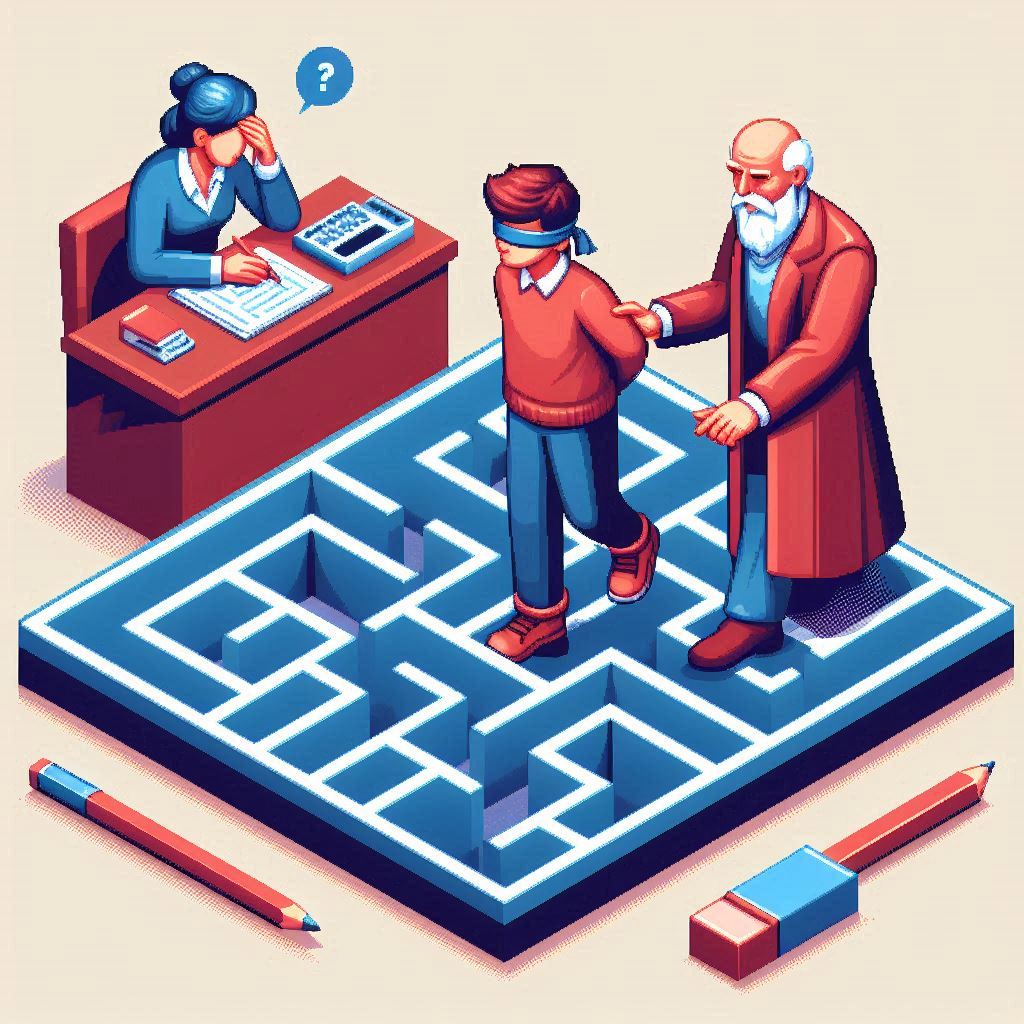

# BM954 SOPs

SOPs for AY2024-25 BM954 BMS MSc Projects

This page outlines SOPs (Standard Operating Procedures) for the AY2024-25 BM954 BMS MSc Projects. Please use the menu in the sidebar to navigate to specific sections and activities.

In general, the SOPs will provide links to detailed instructions and documentation, and then provide a short walkthrough that can be used as an example from which to begin your own work. This is *not* a set of instructions for how to carry out your research project.

**Important**

All activities/procedures on this page assume that you are working on a Linux (including Windows Subsystem Linux) or macOS machine. These instructions have not been tested on a Windows OS.